# STA 207: Assignment I

ChenruiLu_920509665

**Instructions** You may adapt the code in the course materials or any sources (e.g., the Internet, classmates, friends). In fact, you can craft solutions for almost all questions from the course materials with minor modifications. However, you need to write up your own solutions and acknowledge all sources that you have cited in the Acknowledgement section.

Failing to acknowledge any non-original efforts will be counted as plagiarism. This incidence will be reported to the Student Judicial Affairs.

A consulting firm is investigating the relationship between wages and occupation. The file `Wage.csv` contains three columns, which are

- `wage`, the wage of the subject,
- `ethnicity`, the ethnicity of the subject,
- and `occupation`, the occupation of the subject.

We will only use `wage` and `occupation` in this assignment.

```r
Wage=read.csv('Wage.csv');
library(gplots)
attach(Wage)
```

1. Write down a one-way ANOVA model for this data. For consistency, choose the letters from $\{Y,\alpha, \mu, \epsilon\}$ and use the factor-effect form.

   ```r
   wage$occupation=as.factor(Wage$occupation)
   ```

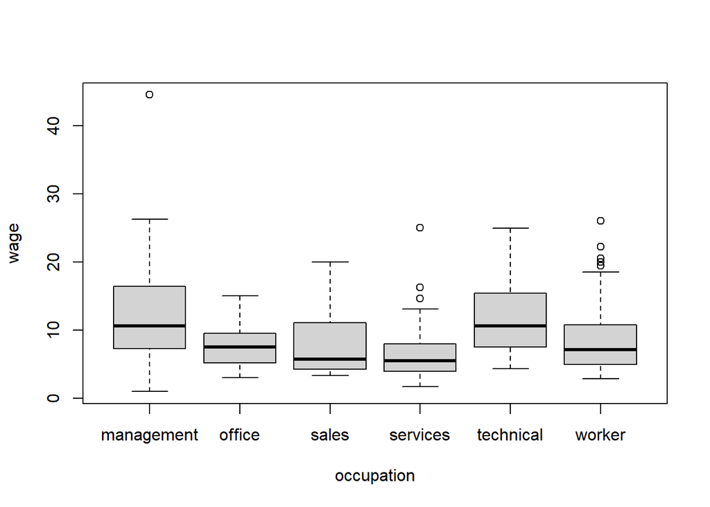

   ```r
   boxplot(wage~occupation,data=Wage)
   ```

$Y_{i,j}=\mu+\alpha_i+\epsilon_{i,j},j=1,...,n_i,i=1,...,6$

where $\{\alpha_i\}$ satisfied that $\Sigma^2_{i=1}n_i\alpha_i=0$ and $\{\epsilon_{i,j}\}$ are i.i.d. $N(0,\sigma^2)$.

In this model, let $r=6$ denote the number of occupations, $Y_{i,j}$ be wages in jth subject for the ith occupation. $\alpha_i$ represent the effect from 6 occupations. The mean effect $\mu$ represents the mean wage in the population. The error $\epsilon_{i,j}$ capture any unexplained effects on wages. values $n_i$ can be found in the following table.

```r
table(Wage$occupation)
```

```
##
## management     office      sales   services  technical     worker
##         55         97         38         83        105        156
```

2. Write down the least squares estimator of $\alpha_i$ for all $i$. Find the expectation and variance of this estimate in terms of $\{n_i\}$ and the parameters of the model.

   let $\hat{\mu_i}= \bar{Y_i}=\frac{1}{n_i}\sum^{n_i}_{j=1}Y_{i,j}$

   $\hat{\mu}=\bar{Y}=\frac{1}{N}\sum^k_{i=1}\sum^{n_i}_{j=1}Y_{i,j}$

   so the least squares estimator of $\alpha_i$ for all i=1,2…,6:

   $\hat{\alpha_i}=\hat{\mu_i}-\hat{\mu}=\bar{Y_i}-\bar{Y}$

   And the expectation and variance of this estimate in terms of {$n_i$} and the parameters of the model are as following:

   $E(\hat{\mu})=\mu$ , $Var(\hat{\mu})=\frac{\sigma^2}{N}$

   $E(\hat{\mu_i})=\mu_i$ , $Var(\hat{\mu_i})=\frac{\sigma^2}{n_i}$

   $E(\hat{\alpha_i})=E(\hat{\mu_i}-\hat{\mu})=\mu_i-\mu=\alpha_i$ , $Var(\hat{\alpha_i})=Var(\hat{\mu}-\hat{\mu})=Var(\bar{Y_i}-\bar{Y})$

   $=Var(\bar{Y_i}-\frac{\sum^k_{s=1}n_s\bar{Y_s}}{N})=Var((1-\frac{n_i}{N})\bar{Y_i}-\frac{\sum_{s\not=i}n_s\bar{Y_s}}{N})$

   $=(1-\frac{n_i}{N})^2Var(\bar{Y_i})+\sum_{s\not=i}\frac{n_s^2}{N^2}Var(\bar{Y_s})$

   $=(1-\frac{n_i}{N})^2\frac{\sigma^2}{n_i}+\sum_{s\not=i}\frac{n_s^2}{N^2}\frac{\sigma}{n_s}$

   $=(\frac{1}{n_i}-\frac{1}{N})\sigma^2$
3. Obtain the main effects plots. Summarize your findings.

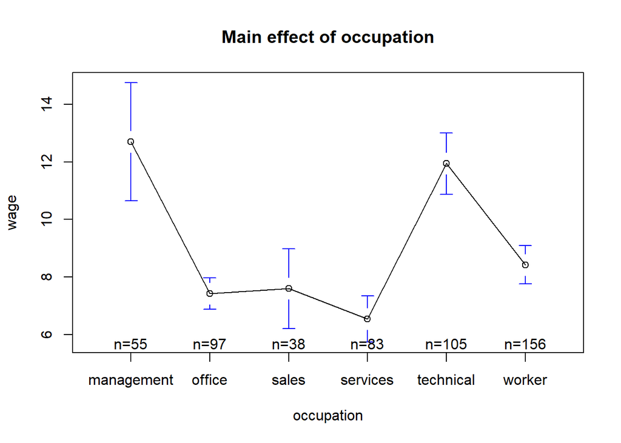

   ```r
   library(gplots)
   plotmeans(wage~occupation,data=Wage,xlab="occupation",ylab="wage",main="Main effect of occupation")
   ```

   Observations:
   - Apparent differences in wages across occupation.
   - Wages have largest variability in management field.
   - Services has the lowest wage.
   - Different sample size under each occupations.
4. Set up the ANOVA table using `R` for your model. Briefly explain this table.

   ```r
   aov1=aov(wage~occupation,data=Wage)
   summary(aov1)
   ```

   ```
   ##              Df Sum Sq Mean Sq F value Pr(>F)
   ## occupation    5   2538   507.5   23.22 <2e-16 ***
   ## Residuals   528  11539    21.9
   ## ---
   ## Signif. codes:  0 '***' 0.001 '**' 0.01 '*' 0.05 '.' 0.1 ' ' 1
   ```

   explanations:
   - The degree of freedom of occupation is 5.
   - The degree of freedom of residuals is 528.
   - Occupations sum of squares is 2538.
   - Residual sum of squares is 11539.
   - Occupations mean of square is 507.5.
   - Residuals mean of square is 21.9.
   - F test statistics is 23.22.
   - P-value is <2e-16.
5. Test whether there is any association between `occupation` and `wage`. In particular, you need to (a) define the null and alternative hypotheses using the notation in Part 1, (b) conduct the test, and (c) explain your test result.

   Null hypothesis: $H_0=\alpha_1=\alpha_2=…=\alpha_6=0$

   Alternative hypothesis: $H_a$: not all $\alpha_i$ are the zero

   According to Part 4, we can see that the F test statistics is 23.22, and the P-value is <2e-16. Therefore, under 0.01 confidence level, the P-value is less than 0.01 which indicates significant difference of wages under different occupations.
1. For the model fitted in Part 4, carry out the necessary diagnostics to check if the model assumptions given in Part 1 are valid. What are your findings?

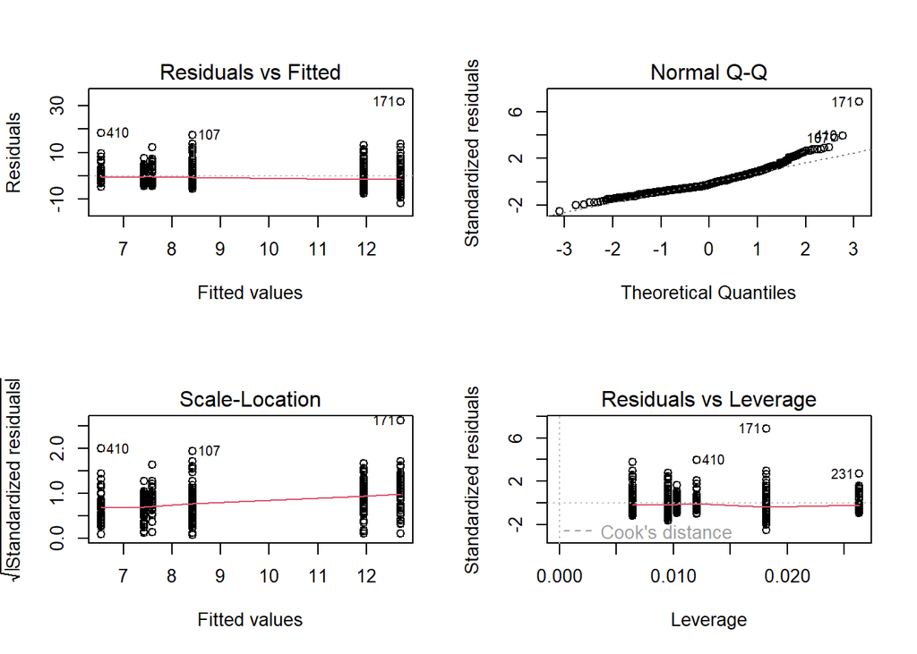

   ```r
   par(mfrow=c(2,2))
   plot(aov1)
   ```

   `examine the assumption of homogeneity of variance for error terms

   `examine the assumption of normality for error terms

   **outliers**

   To test outliers, we use the residuals vs. fitted values plot, and points 410,107,171 are found, which can have a significant impact on normality and homogeneity of variance. To meet assumptions, it can be beneficial to remove outliers.

   **Variance homogeneity**

   Because $n_i$s are not the same(imbalanced design), so the homogeneity of variances can be checked using Bartlett’s ot Levene’s tests.

   ```r
   bartlett.test(wage~occupation,data=Wage)
   ```

   ```
   ##
   ##  Bartlett test of homogeneity of variances
   ##
   ## data:  wage by occupation
   ## Bartlett's K-squared = 94.531, df = 5, p-value < 2.2e-16
   ```

```r
library(car)
leveneTest(wage~occupation,data=Wage)
```

```
## Levene's Test for Homogeneity of Variance (center = median)
##        Df F value    Pr(>F)
## group   5  9.7025 7.043e-09 ***
##       528
## ---
## Signif. codes:  0 '***' 0.001 '**' 0.01 '*' 0.05 '.' 0.1 ' ' 1
```

Both p-values from Bartlett’s and Levene’s tests are less than the significance level of 0.05. This indicates that there is evidence of significantly unequal variances of error terms.

As a result, we can infer that the variations in the different occupations are not homogeneous.

**Normality**

Normal Q-Q plot can be used to verify the residuals are normally distributed. All points should be about in a straight line.

Normality assumption can also be checked by Shapiro-Wilk normality test.

```r
avo_residuals=residuals(object=aov1)
shapiro.test(x=avo_residuals)
```

```
##
##  Shapiro-Wilk normality test
##
## data:  avo_residuals
## W = 0.91749, p-value < 2.2e-16
```

The p-value of this test is below 2.2e-16, which indicates that there is evidence of normality violation. As a result, we can infer that the error terms are not normality.

7. Assuming that the assumptions you made are true, can you statistically conclude if there is one occupation where the mean wage is the highest? Use the most appropriate method (use $\alpha=0.05$) to support your statement.

   For this question, we just need to care about whether the group with the highest weights has significantly higher weights than the group with the second highest weights.

   Tukey-Kramer method works for pairwise comparisons, so it is the most appropriate methods to construct simultaneous confidence intervals for all pairwise comparisons.

   ```r
   library(dplyr)
   alpha=0.05
   Wage%>%group_by(occupation)%>%summarise(Mean=mean(wage))
   ```

   ```
   ## # A tibble: 6 × 2
   ##   occupation  Mean
   ##   <chr>      <dbl>
   ## 1 management 12.7
   ## 2 office      7.42
   ## 3 sales       7.59
   ## 4 services    6.54
   ## 5 technical  11.9
   ## 6 worker      8.43
   ```

   From the above table, we can see that the largest wage is in management, and the second largest is in technical.

   ```r
   T.ci=TukeyHSD(aov1,conf.level = 1-alpha)
   T.ci
   ```

   ```
   ##   Tukey multiple comparisons of means
   ##     95% family-wise confidence level
   ##
   ## Fit: aov(formula = wage ~ occupation, data = Wage)
   ##
   ## $occupation
   ##                            diff         lwr       upr     p adj
   ## office-management    -5.2814227 -7.53836588 -3.024479 0.0000000
   ## sales-management     -5.1113684 -7.93192217 -2.290815 0.0000046
   ## services-management  -6.1665301 -8.49132800 -3.841732 0.0000000
   ## technical-management -0.7565714 -2.98218646  1.469044 0.9265714
   ## worker-management    -4.2775256 -6.37435762 -2.180694 0.0000001
   ## sales-office          0.1700543 -2.38885725  2.728966 0.9999657
   ## services-office      -0.8851074 -2.88440478  1.114190 0.8032931
   ## technical-office      4.5248513  2.64180401  6.407898 0.0000000
   ## worker-office         1.0038970 -0.72503588  2.732830 0.5584749
   ## services-sales       -1.0551617 -3.67411581  1.563792 0.8589942
   ## technical-sales       4.3547970  1.82347368  6.886120 0.0000170
   ## worker-sales          0.8338428 -1.58502882  3.252714 0.9223496
   ## technical-services    5.4099587  3.44609529  7.373822 0.0000000
   ## worker-services       1.8890045  0.07238631  3.705623 0.0361288
   ## worker-technical     -3.5209542 -5.20878674 -1.833122 0.0000001
   ```

   From the table, we can see that the row of ‘technical-management’ shows the CI covers 0, so we cannot reject the null hypothesis $H_0:\mu_1=\mu_5$. The occupation with the largest mean wage can be either management or technical. We cannot conclude that there is a occupation with the largest mean wage at the significance level 0.05.
8. Consider a one-way ANOVA model with fixed effects $Y_{i,j}=\mu + \alpha_i+ \epsilon_{i,j}, \ j=1,\ldots, n_i, i =1,\ldots, r$ where $\{ \alpha_i\}$ satisfies that $\sum_{i} n_i \alpha_i=0$ and $\{\epsilon_{i,j}\}$ are i.i.d. $N(0,\sigma^2)$. For the above model, write down the loss function associated with least squares, denoted as $L_1(\mu,\alpha)$, and write down the log-likelihood, denoted as $L_2(\mu,\alpha)$.

   Since $Y_{i,j}\sim_{iid}N(\mu+\alpha_i,\sigma^2)$

   the loss function is $L_1(\mu,\alpha_i,\sigma)=\sum_{i=1}^r\sum_{j=1}^{n_i}(Y_{i,j}-\mu-\alpha_i)^2$

   the log-likelihood is $L_2(\mu,\alpha_i,\sigma)=\sum_{i=1}^r\sum_{j=1}^{n_i}log\{\frac{1}{\sqrt{2\pi\sigma^2}}exp[-\frac{(Y_{i,j}-\mu-\alpha_i)^2}{2\sigma^2}]\}$
9. Find the maximum likelihood estimator of $\mu$ and $\alpha$ using the log-likelihood $L_2(\mu,\alpha)$ in Question 8.

   Since $L_2(\mu,\alpha_i,\sigma)=\sum_{i=1}^6\sum_{j=1}^{n_i}log\{\frac{1}{\sqrt{2\pi\sigma^2}}exp[-\frac{(Y_{i,j}-\mu-\alpha_i)^2}{2\sigma^2}]\}$,

   the partial derivation of $L_2$ is

   $\frac{\partial{l}}{\partial\mu}=\frac{1}{\sigma^2}\sum^r_{i=1}\sum^{n_i}_{j=1}(Y_{i,j}-\mu-\alpha_i)=0$

   $\frac{\partial{l}}{\partial\alpha_i}=\frac{1}{\sigma^2}\sum^{n_i}_{j=1}(Y_{i,j}-\mu-\alpha_i)=0,i=1,...,r$

   Therefore, the maximum likelihood estimator of $\mu$ and $\alpha$ is

   $\hat{\mu}=\bar{Y}$

   $\alpha_i=\bar{Y_i}-\bar{Y}, i=1,…,r$

## Acknowledgement

I would like to acknowledge that most of the codes and explanation are guided by instructors’ notes and TA’s note. For the question 9, I learned from *Probability and Mathematics Statistics*, Shisong Mao.